# 1. The fitness calculation depends on the cohort spacing

```r
library(tree)
```

This has a useful “run.ebt” function that will save some book-keeping. The resample/rescaling will help, too.

```r
source("../reference/reference-fun.R")
```

Some functions for exploring introduction times.

```r
cohort.introduction.times <- function(max.time, multiplier=0.2,
                                      min.step.size=1e-05,
                                      max.step.size=2) {
  if (min.step.size <= 0)
    stop("The minimum step size must be greater than zero")
  trim <- function(x)
    max(min(x, max.step.size), min.step.size)
  times <- numeric(0)
  dt <- time <- 0
  while (time <= max.time) {
    times <- c(times, time)
    time <- time + trim(time * multiplier)
  }
  times
}

interleave <- function(x) {
  n <- length(x)
  xp <- c(x[-n] + diff(x)/2, NA)
  c(rbind(x, xp))[-2*n]
}

insert.time <- function(i, x) {
  j <- seq_len(i)
  c(x[j], (x[i] + x[i+1])/2, x[-j])
}

run.with.times <- function(times, ebt) {
  sched <- new(CohortSchedule, 1)
  sched$set_times(times, 1)
  sched$max_time <- max(times)
  ebt$reset()
  ebt$cohort_schedule <- sched
  run.ebt(ebt)
}
```

This should really move into tree

```r
calculate.fitness <- function(ebt, res=NULL, integrate=TRUE) {
  a <- ebt$cohort_schedule$times(1)
  p <- ebt$parameters
  d <- new(Disturbance, p$parameters[["mean_disturbance_interval"]])
  pa <- sapply(a, function(ai) d$density(ai))
  Pi_0 <- p$parameters[["Pi_0"]]
  if (is.null(res)) {
    # TODO: provide proper way of getting this out; won't work at all
    # for a multi-species system.
    seeds <- matrix(ebt$ode_values, 4)[3,] * Pi_0
  } else {
    seeds <- res$values$seeds[nrow(res$values$seeds),] * Pi_0
    if (length(seeds) != length(pa))
      stop("Incompatible output")
  }
  if (integrate)
    trapezium(a, pa * seeds) * p$seed_rain
  else
    cbind(a, pa * seeds * p$seed_rain)
}

p <- new(Parameters)
p$add_strategy(new(Strategy))

p$seed_rain <- 1.1
p$set_parameters(list(patch_area=1.0)) # See issue #13
```

Relatively quick control settings:

```r
ctrl.new <- list()
ctrl.new$environment_light_rescale_usually <- TRUE
ctrl.new$environment_light_tol <- 1e-4
ctrl.new$plant_assimilation_rule <- 21
ctrl.new$plant_assimilation_over_distribution <- FALSE
ctrl.new$plant_assimilation_tol <- 1e-4
ctrl.new$ode_tol_rel <- 1e-4
ctrl.new$ode_tol_abs <- 1e-4
ctrl.new$ode_step_size_max <- 5
ctrl.new$cohort_gradient_direction <- -1
ctrl.new$cohort_gradient_richardson <- FALSE
p$set_control_parameters(ctrl.new)

ebt <- new(EBT, p)
```

# 1. The fitness calculation depends on the cohort spacing

Three progressively more closely spaced times:

```r
tt.1 <- cohort.introduction.times(104)
tt.2 <- interleave(tt.1)
tt.3 <- interleave(tt.2)

res.1 <- run.with.times(tt.1, ebt)
w.1 <- calculate.fitness(ebt)

res.2 <- run.with.times(tt.2, ebt)
w.2 <- calculate.fitness(ebt)

res.3 <- run.with.times(tt.3, ebt)
w.3 <- calculate.fitness(ebt)
```

Fitness increases as time is cohorts are introduced more finely, though at a potentially saturating rate. We're doing lots more work at the more refined end though!

```r
c(w.1, w.2, w.3)
```

```
## [1] 540.2 592.2 600.7
```

# 2. Where is this difference coming from?

Are we just geting more accurate resolution of some of the time courses? Is it mostly coming from the beginning individuals or the end ones?

By brute force, split cohorts along the time course and see how we do; that might give some clue:

```r
run.with.insert <- function(i, t, ebt) {
  res <- run.with.times(insert.time(i, t), ebt)
  calculate.fitness(ebt)
}
```

This takes a little while because we're re-running the entire simulation (about 3 minutes). This would be a bit easier to do if we could easily restart the entire simulation because we could just to that for the point just before the new introduction. See issue #40.

```r
i <- seq_len(length(tt.1) - 1)
res <- sapply(i, run.with.insert, tt.1, ebt)
```

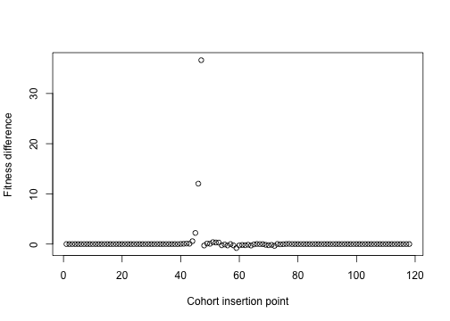

```r
dw.1 <- res - w.1
tm.1 <- (tt.1[-1] + tt.1[-length(tt.1)])/2

plot(dw.1, xlab="Cohort insertion point", ylab="Fitness difference")
```

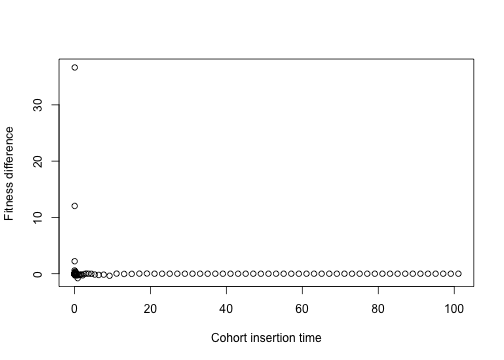

```r
plot(tm.1, dw.1, xlab="Cohort insertion time",
     ylab="Fitness difference")
```

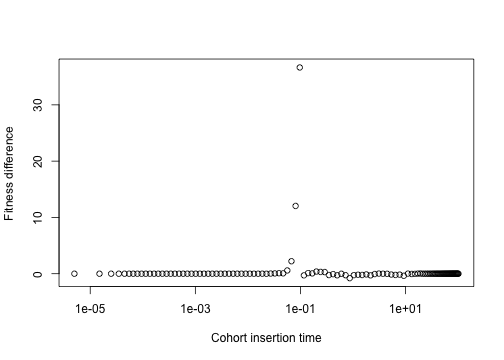

```r
plot(tm.1, dw.1, xlab="Cohort insertion time",
     ylab="Fitness difference", log="x")
```

The reason for the change in total fitness is how we compute the contribution to fitness. Pulling apart the fitness calculations above to get the per-cohort contributions:

```r
tmp <- calculate.fitness(ebt, integrate=FALSE)
```

And plotting this with the position (vertical line) of the most influential cohort introduction time. Dashed vertical lines are the 5 next most important splits, from darkest (2nd most important) to lightest (6th most important).

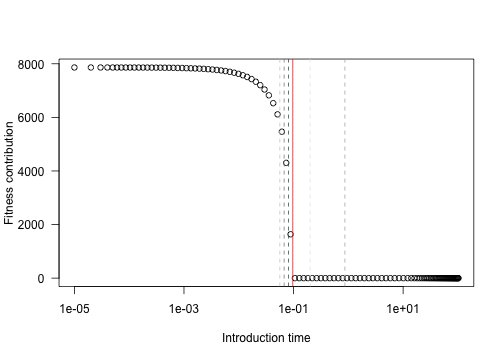

```r
plot(tmp[-1,], log="x", las=1,
     xlab="Introduction time", ylab="Fitness contribution")
abline(v=tm.1[order(abs(dw.1), decreasing=TRUE)[2:6]],
       col=grey.colors(5), lty=2)
abline(v=tm.1[which.max(abs(dw.1))], col="red")
```

Here is the same figure on a non-log basis, covering the important range of times.

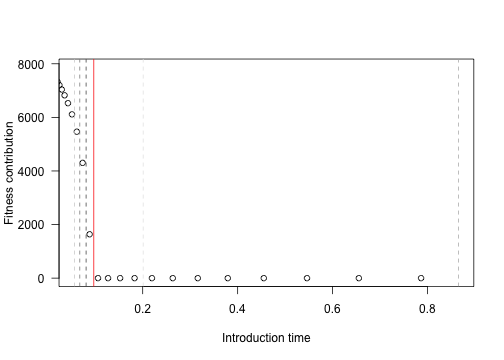

```r
r <- range(tm.1[order(abs(dw.1), decreasing=TRUE)[1:6]])
plot(tmp[-1,], las=1, xlim=r,
     xlab="Introduction time", ylab="Fitness contribution")
abline(v=tm.1[order(abs(dw.1), decreasing=TRUE)[2:6]],
       col=grey.colors(5), lty=2)
abline(v=tm.1[which.max(abs(dw.1))], col="red")
```

3: What is it about this point that is important?

```r
res.0 <- run.with.times(tt.1, ebt)
idx <- which.max(abs(dw.1))
res.cmp <- run.with.times(insert.time(idx, tt.1), ebt)
```

Confirm where the new cohort is (at idx)

```r
identical(res.0$times, res.cmp$times[-idx])
```

```
## [1] TRUE
```

Look at the light environments over time

```r
env.0   <- res.0$light.env
env.cmp <- res.cmp$light.env[-idx]

show.env <- function(i) {
  plot(env.0[[i]], type="o")
  lines(env.cmp[[i]], col="red", type="o", cex=.5, lty=2)
}
```

These give basically the same light environment until 74 – at this point they even have the same dimensions:

```r
n <- cbind(sapply(env.0, nrow),
           sapply(env.cmp, nrow))
idx2 <- which(n[,1] != n[,2])[1]
```

Differences by this point are fairly small

```r
all.equal(env.0[idx:(idx2 - 1)],
          env.cmp[idx:(idx2 - 1)], tolerance=1e-4)
```

```
## [1] TRUE
```

After this point, the version with the additional cohort has *greater* canopy openness at the bottom of the light environment (so below 10m tall, there is more light getting through).

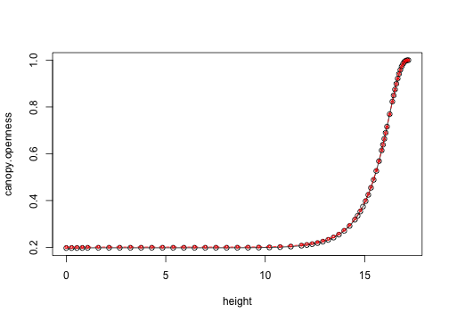

```r
show.env(idx2 + 5)
```

This becomes a wedge, with another possible round of recruitment, causing a second drop in light at about 3m:

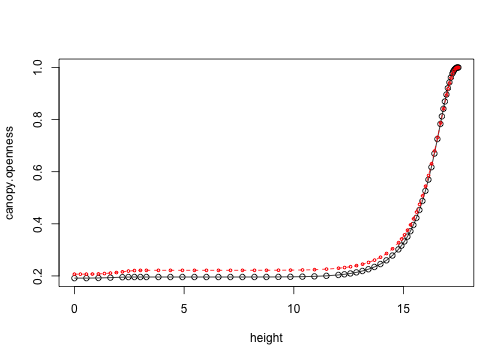

```r
show.env(idx2 + 9)
```

By the time a similar wedge starts appearing in the first version, the wedge in the new verion has steepend dramatically – now the light environment is lower for very small heights than for medium heights:

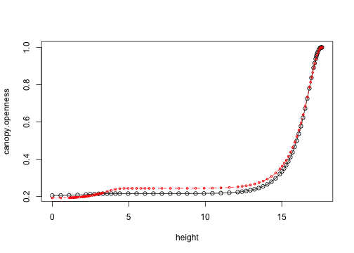

```r
show.env(idx2 + 12)
```

Then, the light environment at the forest floor equalises for the two versions, but the position of the wedge varies between runs:

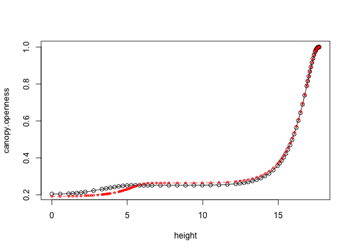

```r
show.env(idx2 + 15)
```

that difference persists:

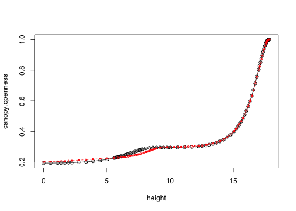

```r
show.env(idx2 + 20)
```

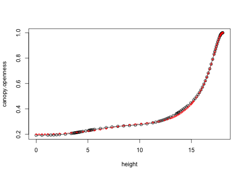

```r
show.env(idx2 + 30)
```

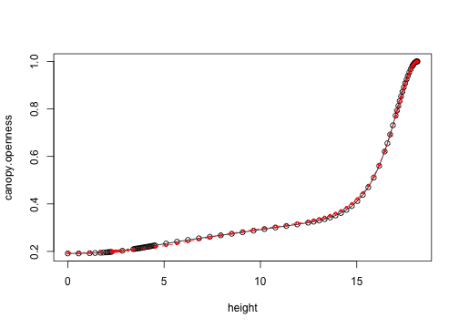

```r
show.env(idx2 + 40)
```

The final light environment is fairly similar though

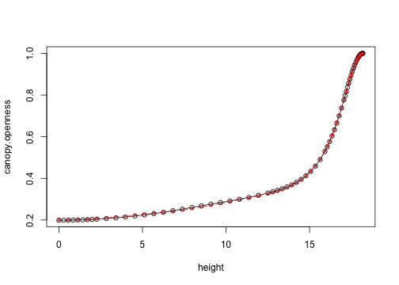

```r
show.env(length(env.0))
```